# Live session Unit 03 assignment

Olga Tanyuk

January 26, 2018

### 1. GitHub Cloning

- $ mkdir Unit_3 # create a new directory
- $ cd Unit_3 # navigate to the appropriate directory
- $ git clone https://github.com/caesar0301/awesome-public-datasets # clone the repository to it

### 2. Data Summary: From this cloned repo, please extract titanic.csv.zip. To be clear, this does not have to be done in Git or command line.

1. In R, please read in titanic.csv via either read.table() or read.csv(), assigning it to df. This dataset follows the passengers aboard the Titanic, including their fees paid, rooms rented, and survivorship status.

```r
df <- read.csv("~/R_files/titanic.csv")
```

2. Output the respective count of females and males aboard the Titanic. Plot the frequency of females and males. Be sure to give an accurate title and label the axes.

```r
Sex <- df$Sex
Sum_Male <- sum("male" == Sex)
Sum_Female <- sum("female" == Sex)
Sum_Male
```

```
## [1] 577
```

```r
Sum_Female
```

```
## [1] 314
```

Also we could count females and males aboard using function ‘table’:

```r
table(df$Sex)
```

```
##
## female   male
##    314    577
```

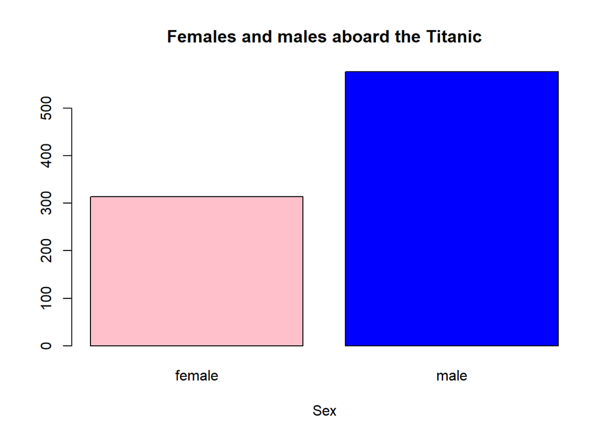

```r
barplot(table(df$Sex), xlab="Sex", main="Females and males aboard the Titanic", col = c('pink', 'blue'))
```

3. Please use one apply function (to review: swirl() modules 11, 12) to output the means of Age, Fare, and Survival.

```r
data <- list(Age = df$Age, Fare = df$Fare, Survived = df$Survived)
lapply(data, mean)
```

```
## $Age
## [1] NA
##
## $Fare
## [1] 32.20421
##
## $Survived
## [1] 0.3838384
```

We got NA for Age data, since there we have NA elements. Lets calculate the Mean of the Ages using next function:

```r
mean(df$Age, na.rm=T)
```

```
## [1] 29.69912
```

### 3. You research sleep and just got your first data set. Later, you’ll have another dataset with the same column names, so you want to create a helper function that you can analyze this dataset and the next. Load sleep_data_01.csv (found at http://talklab.psy.gla.ac.uk/L1_labs/lab_1/homework/index.html). Questions 3A through 3D should be answered in function(x){}. 3E can be outside of the function.

1. Create objects for the median Age, the minimum and maximum Duration of sleep, and the mean and standard deviation of the Rosenberg Self Esteem scale (RSES). You may need to specify a few options like in Problem 2 and live session.
2. Create a data.frame object called report: it should consist of the median age, the RSES mean and standard deviation respectively divided by five (since there are five questions and these scores are summed), and the range of Duration (the statistical definition of range; it should be a single number.)
3. Change the column names of this data.frame to MedianAge, SelfEsteem, SE_SD, and DurationRange.
4. Round the report to at most 2 digits: leave this as the closing line to the function.
5. Finally, run the function on your sleep data to show the output.

```r
sleep_data_01 <- read.csv("~/R_files/sleep_data_01.csv")
Report <- function(x, y, z) {
         med <- median(x, na.rm=T)
         min <- min(y, na.rm=T)
         max <- max(y, na.rm=T)
         mea <- mean(z, na.rm=T)/5
         sd <- sd(z, na.rm=T)/5
         range <- max-min
         Function <- c("MedianAge", "SelfEsteem", "SE_SD", "DurationRange")
         Report <- round(c(med, mea, sd, range),2)
         d <- data.frame(Function,Report)
         d
         }
Report(x=sleep_data_01$Age, y=sleep_data_01$Duration, z=sleep_data_01$RSES)
```

```
##        Function Report
## 1     MedianAge  14.00
## 2    SelfEsteem   3.62
## 3         SE_SD   1.24
## 4 DurationRange   7.00
```